# Regione Lazio, parametro: tmax

Identificazione delle serie potenzialmente utili al:

- calcolo dei trend di lungo periodo
- al calcolo dei valori climatologici 1991-2020

Le serie identificate iniziano non piu' tardi del **2001** e terminano non prima del **2015**. La disponibilita' e la continuita' delle serie è stata verificata a livello annuale.

👉 I dati giornalieri delle serie identificate come valide sono state salvate sul file **tmax.lazio.serie_valide.csv**.

Per il calcolo dei valori mensili sono stati utilizzati i criteri del WMO:

- la regola del 5/10 per i dati giornalieri di temperatura
- 0 dati mancanti per i dati giornalieri di precipitazione

### Sintesi dati

| Numero di serie in anagrafica | Numero di serie con almeno un anno valido | Numero di serie valide |
| --- | --- | --- |
| 107 | 73 | 22 |

Per la regione Lazio sono disponibili 107 stazioni in anagrafica. Le serie che per il parametro tmax hanno almeno un valore annuale valido sono **73** (non tutte le stazioni in anagrafica hanno serie di dati per tutti e tre i parametri precipitazione, tmax e tmin). Le serie potenzialmente utili al calcolo dei valori climatologici 1991-2020/trend di lungo periodo sono **22**. In particolare:

- il numero di serie potenzialmente utili al calcolo dei valori climatologici 1991-2020/trend di lungo periodo con almeno una stazione limitrofa nel raggio di 2 km è **0**.
- il numero di serie potenzialmente utili al calcolo dei valori climatologici 1991-2020/trend di lungo periodo prive di stazioni limitrofe nel raggio di 2 km è **22**.

### Reti di provenienza delle serie

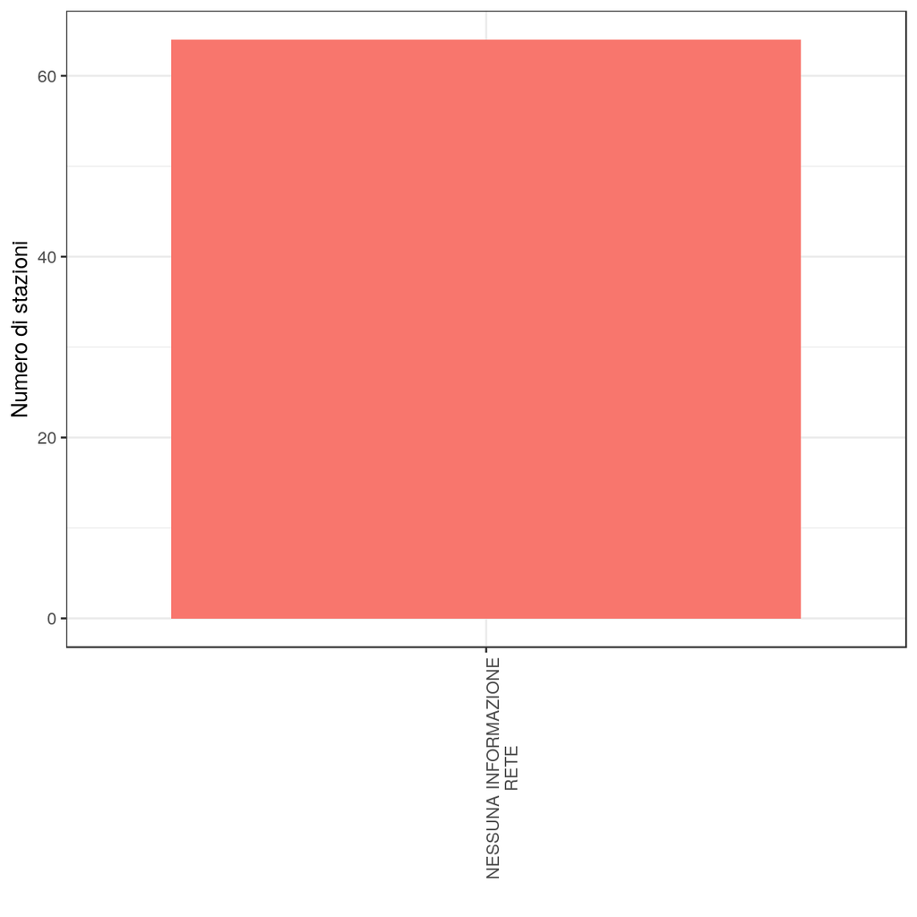

Distinguiamo due casi:

- stazioni che nel raggio di 2 km hanno stazioni limitrofe
- stazioni che nel raggio di 2 km non hanno stazioni limitrofe

In entrambi i casi vogliamo identificare serie sufficientemente lunghe e complete. L'analisi di completezza e continuità delle serie con stazioni limitrofe viene fatta dopo aver unificato le serie.

**Quando uniamo due serie limitrofe?**

Due serie limitrofe vengono unite per generare una nuova serie "unione" quando:

- le due serie si sovrappongono temporalmente solo parzialmente oppure
- le due serie sono totalmente disgiunte

Quando due serie limitrofe si sovrappongono completamente dal punto di vista temporale vengono analizzate separatamente e nessuna serie unione viene generata.

### Anagrafica serie valide

Qui e' possibile scaricare l'anagrafica di tutte le serie identificate come potenzialmente utili al calcolo dei climatologici 1991-2020 e/o al calcolo dei trend di lungo periodo. Questa anagrafica include la selezione finale di tutte le serie (che abbiano serie limitrofe o meno).

Selezionando uno o piu' righe (cliccando con il mouse sulle righe di interesse della tabella) vengono automaticamente filtrate le stazioni sulla mappa. Ad esempio, per selezionare le serie che iniziano dal 1961, cercare mediante il box di testo 1961, quindi selezionare con il mouse le righe trovate. Ricordarsi di deselezionare le righe della tabella prima di iniziare una nuova selezione.

|  | SiteID | SiteCode | SiteName | Longitude | Latitude | Elevation | Elevation_flag | FullSiteCode | cod_rete | cod_reg | nota | nome_rete | annoInizio | annoFine | tipo |
| --- | --- | --- | --- | --- | --- | --- | --- | --- | --- | --- | --- | --- | --- | --- | --- |
| 1 | 240 | 111600 | Roma Macao | 12.5072 | 41.9039 | 56 | 1 | OD:111600 |  | 12 |  | NESSUNA INFORMAZIONE RETE | 1965 | 2020 | sito3 |
| 2 | 273 | 199400 | Marta a Tarquinia | 11.7425 | 42.2569 | 50 | 1 | OD:199400 |  | 12 |  | NESSUNA INFORMAZIONE RETE | 1999 | 2018 | sito3 |
| 3 | 274 | 199500 | Montefiascone | 12.0228 | 42.53 | 516 | 1 | OD:199500 |  | 12 |  | NESSUNA INFORMAZIONE RETE | 1995 | 2020 | sito3 |
| 4 | 275 | 199600 | Allumiere | 11.9086 | 42.1578 | 568 | 1 | OD:199600 |  | 12 |  | NESSUNA INFORMAZIONE RETE | 1964 | 2020 | sito3 |
| 5 | 276 | 199700 | Civitavecchia | 11.7853 | 42.0967 | 7 | 1 | OD:199700 |  | 12 |  | NESSUNA INFORMAZIONE RETE | 1961 | 2020 | sito3 |
| 6 | 278 | 199900 | Bracciano | 12.175 | 42.1019 | 214 | 1 | OD:199900 |  | 12 |  | NESSUNA INFORMAZIONE RETE | 1964 | 2020 | sito3 |
| 7 | 281 | 200600 | Leonessa | 12.9536 | 42.5786 | 929 | 1 | OD:200600 |  | 12 |  | NESSUNA INFORMAZIONE RETE | 1961 | 2020 | sito3 |
| 8 | 282 | 200800 | Posticciola | 12.9419 | 42.2336 | 626 | 1 | OD:200800 |  | 12 |  | NESSUNA INFORMAZIONE RETE | 1971 | 2020 | sito3 |
| 9 | 283 | 200900 | Poggio Mirteto | 12.6953 | 42.27 | 353 | 1 | OD:200900 |  | 12 |  | NESSUNA INFORMAZIONE RETE | 1961 | 2020 | sito3 |
| 10 | 285 | 201200 | Ardea | 12.5369 | 41.6117 | 22 | 1 | OD:201200 |  | 12 |  | NESSUNA INFORMAZIONE RETE | 1961 | 2020 | sito3 |

[output cut: 12 more lines]

## Disponibilità dati

Il grafico sulla disponibilità dei dati rappresenta i dati aggregati a livello annuale. Il `grigio` corrisponde a undato disponibile, il `nero` corrisponde a un dato mancante. Ogni colonna rappresenta una serie di dati annuali dal 1961 (parte alta del grafico) a 2020 (in basso).

### Serie senza stazioni limitrofe

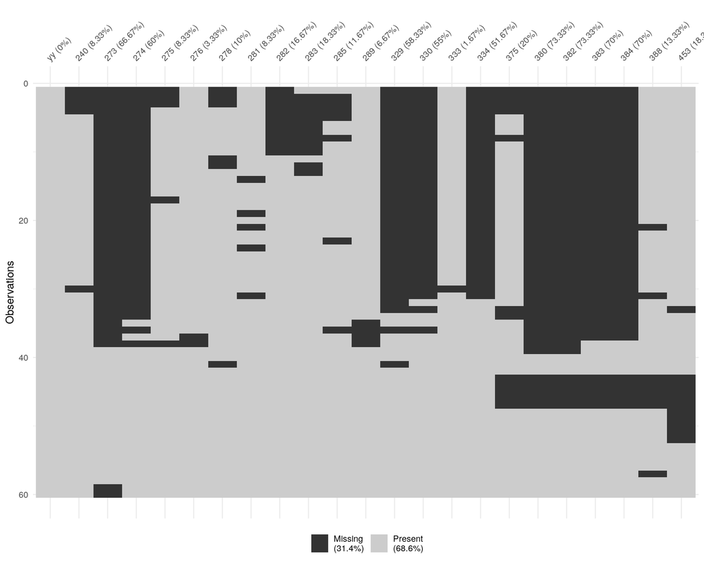

### Distribuzione spaziale delle serie identificate

In blu e in rosso sono identificate le stazioni identificate come "valide" fra quelle che hanno una stazione limitrofa nel raggio di 2 km.

In verde sono riportate le stazioni identificate come "valide" prive di stazioni limitrofe nel raggio di 2 km.

[interactive chart not shown]

### Grafici serie

#### Serie valide (serie senza stazioni limitrofe)

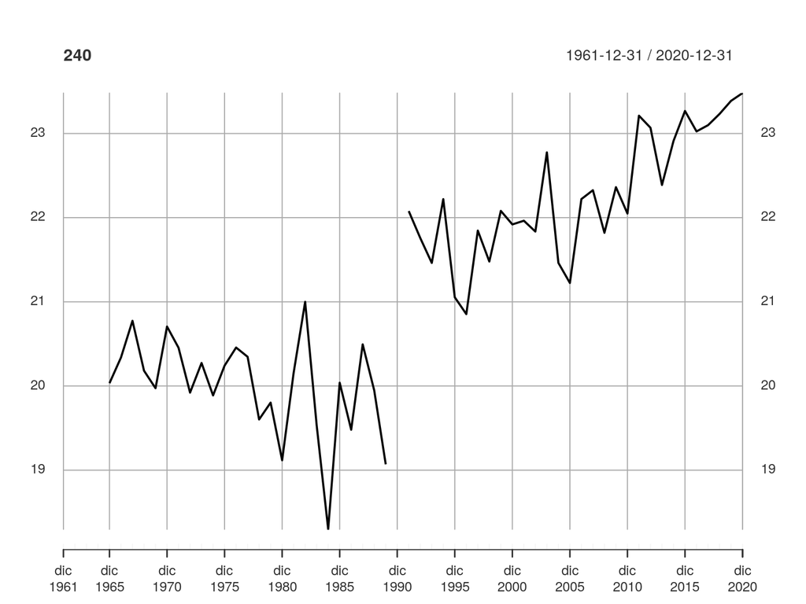

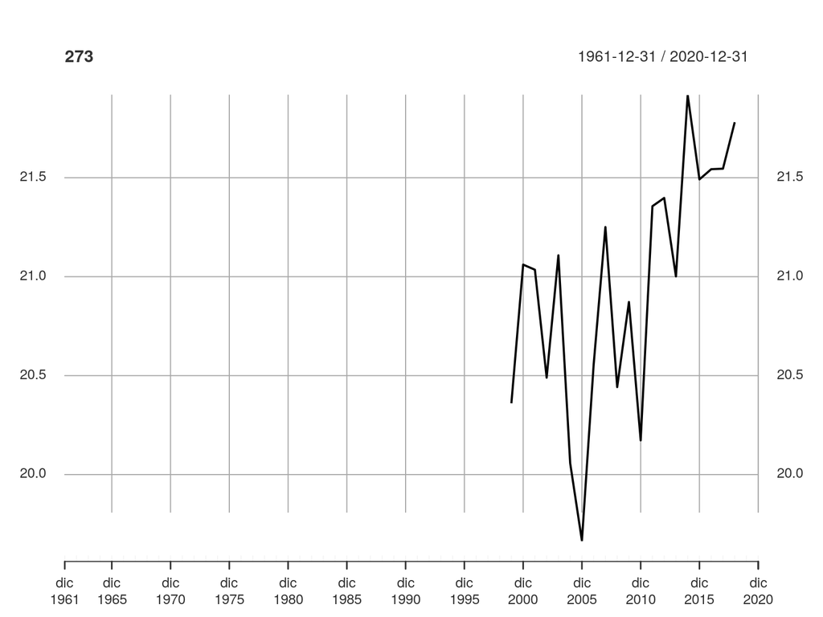

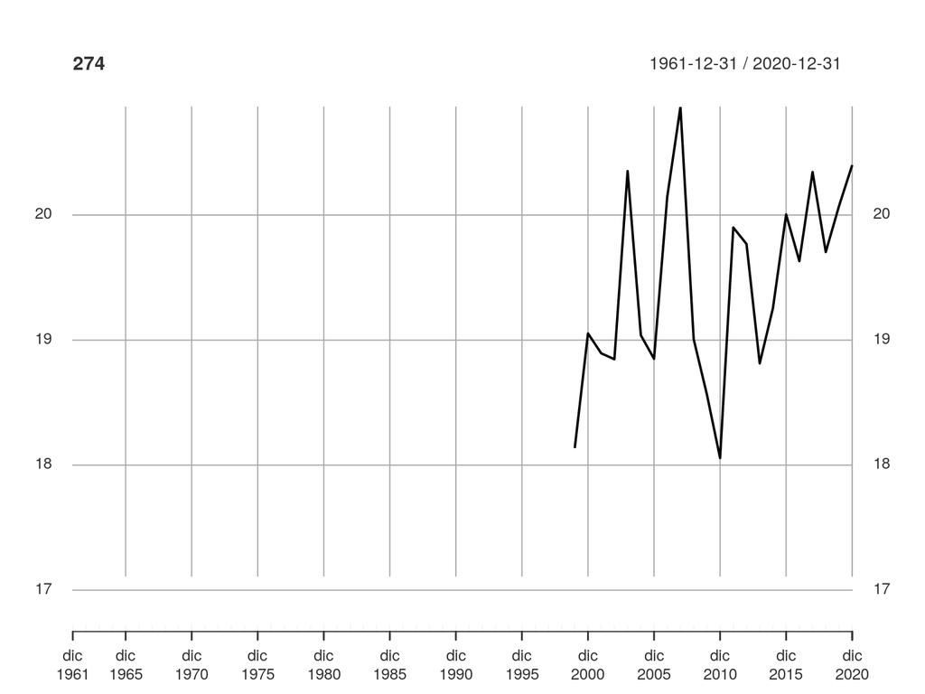

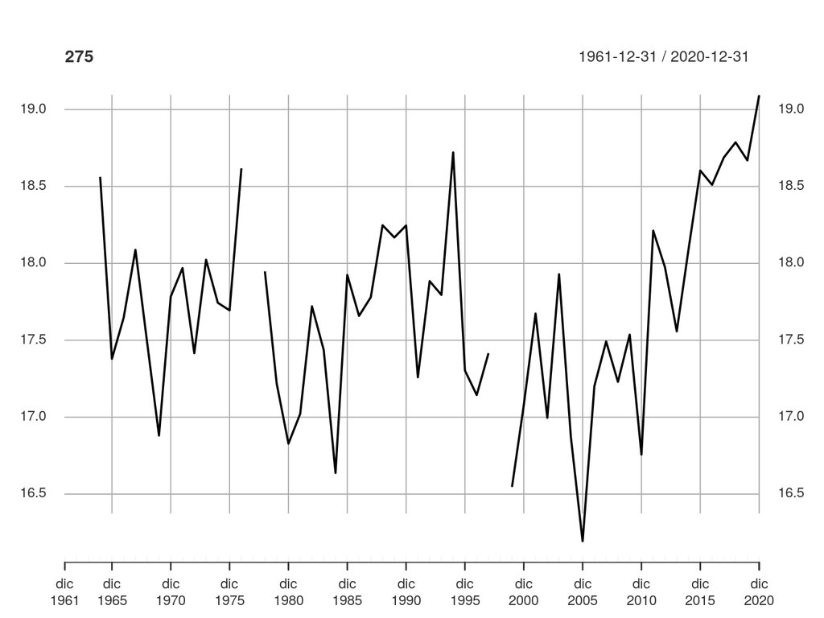

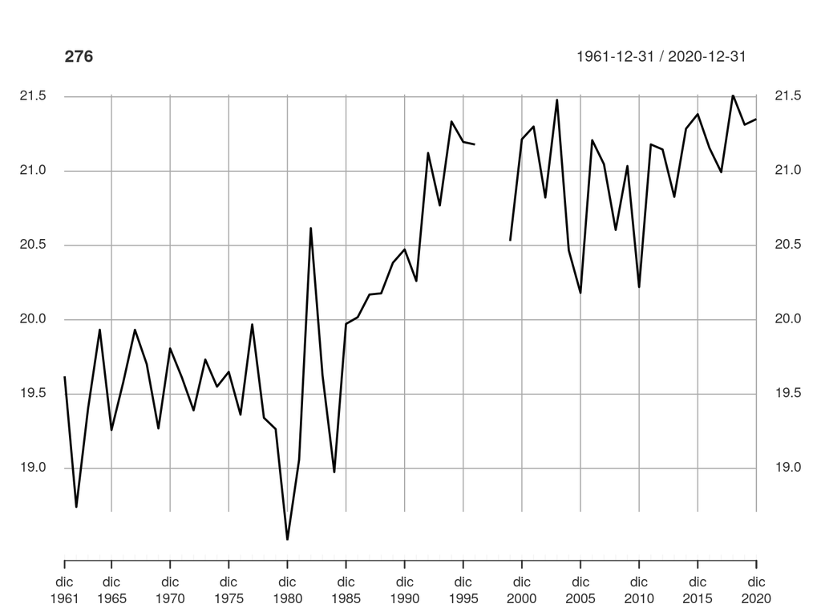

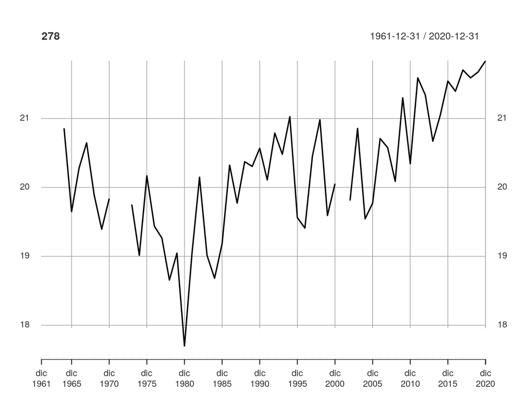

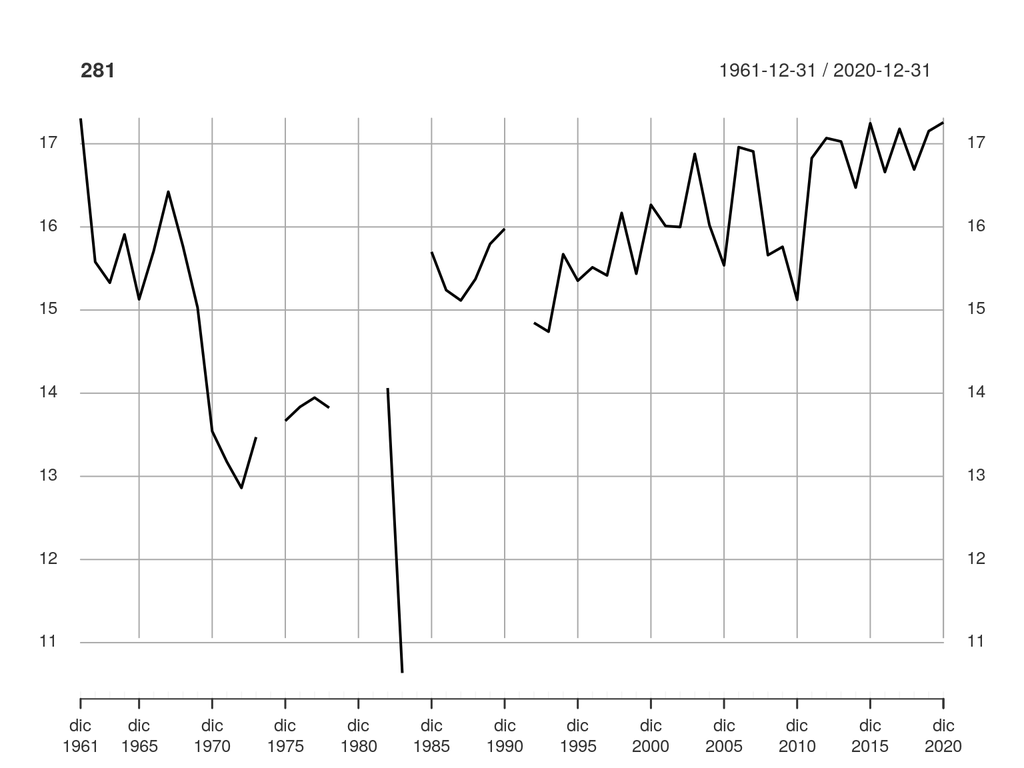

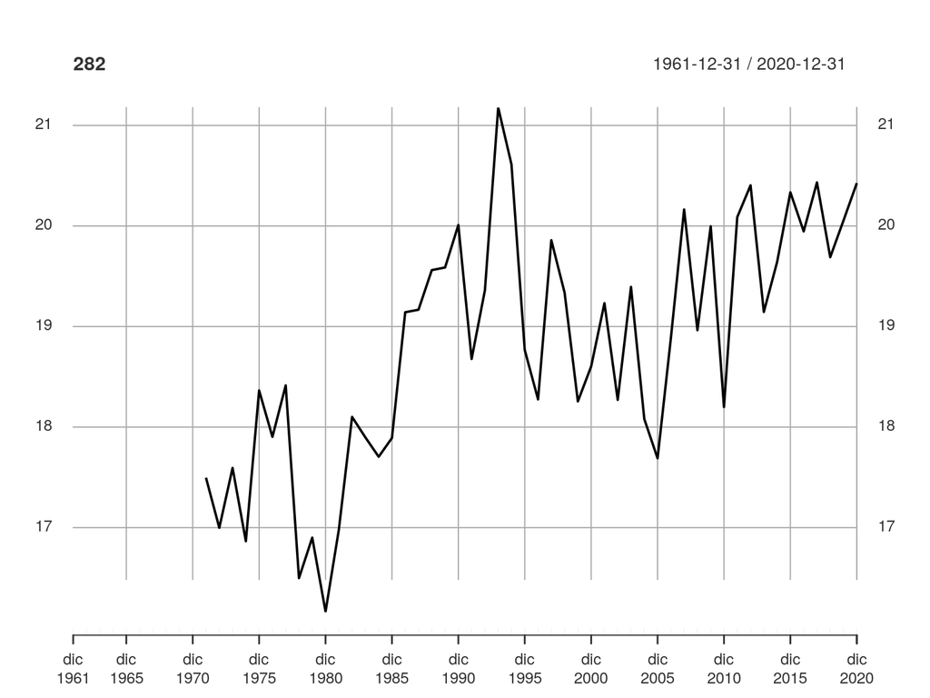

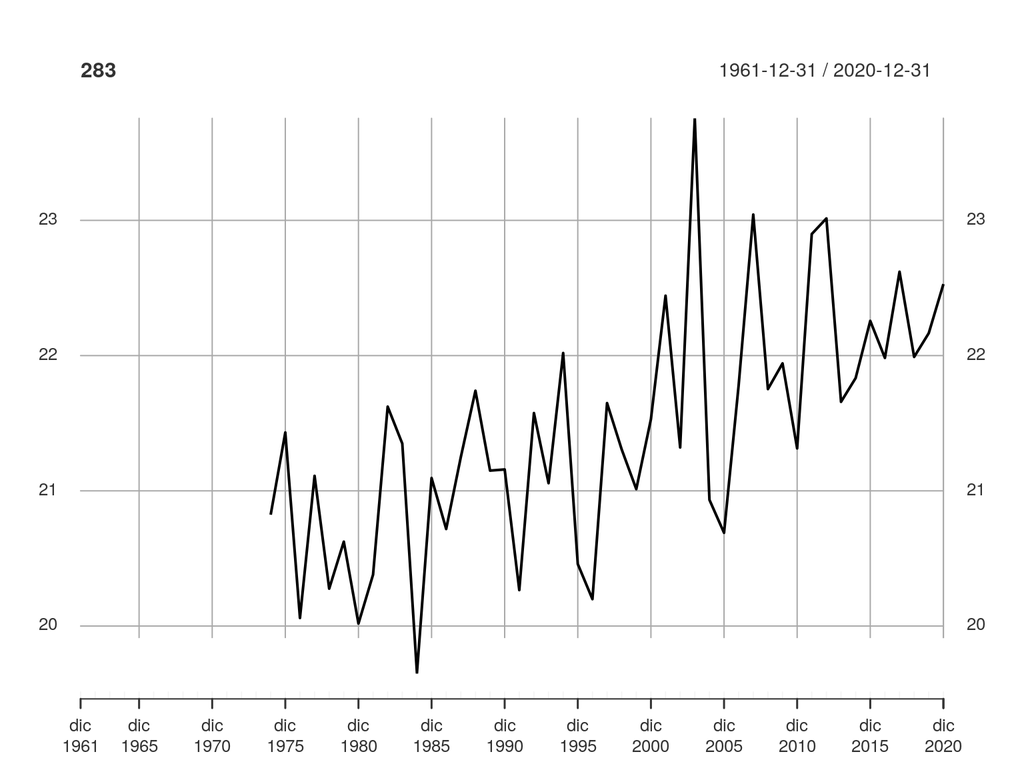

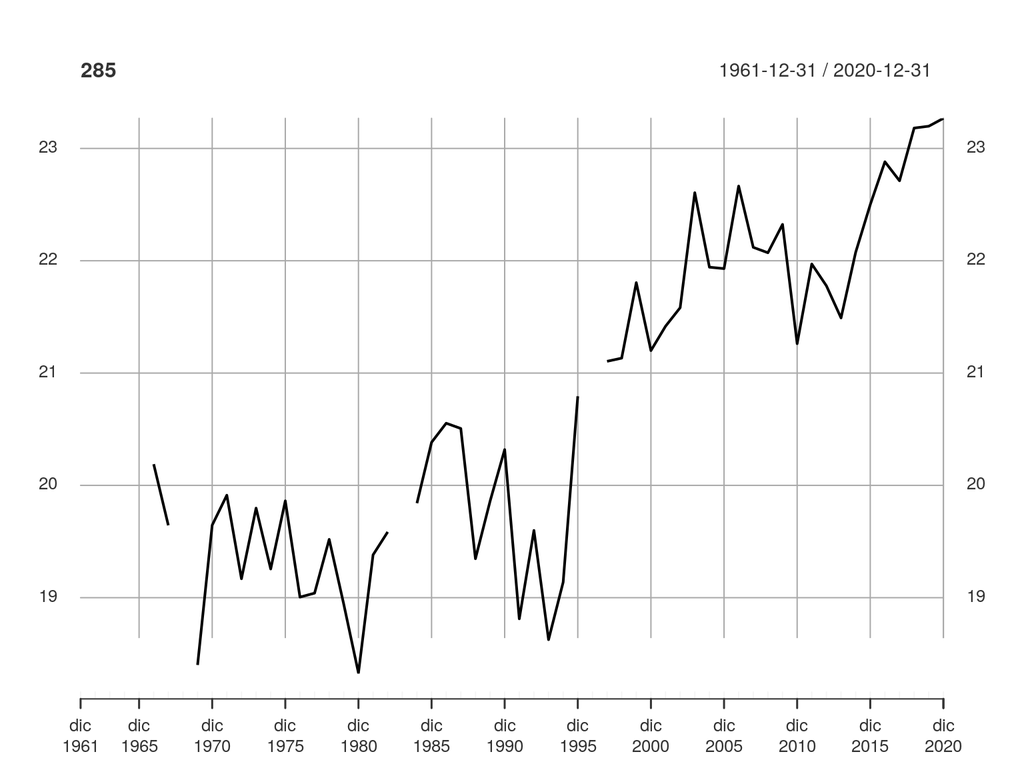

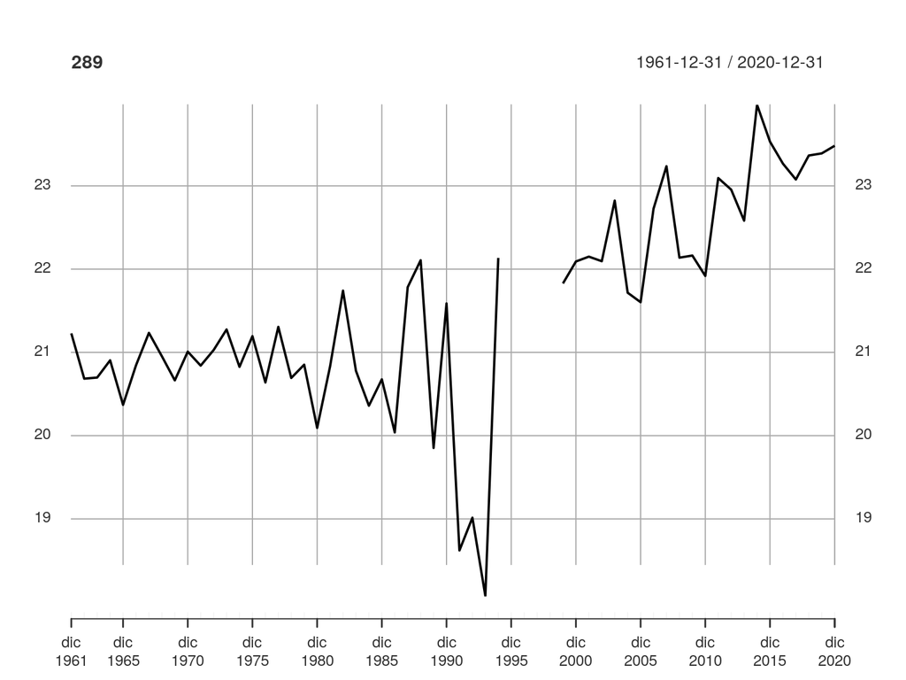

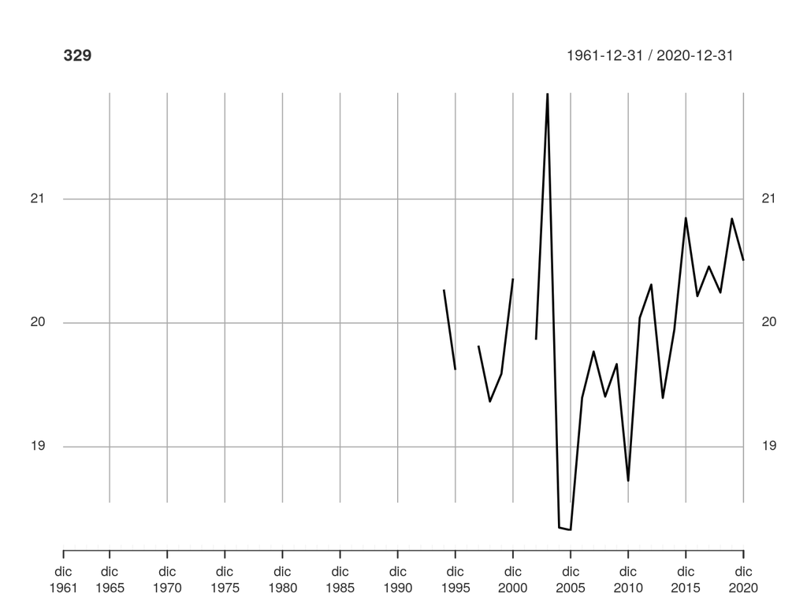

[10 more figures not shown]